# Análise de Textos

06 de Maio de 2021

## Sumário

Nesses slides trataremos sobre os seguintes tópicos do método **Text Mining**:

1. Introdução;
2. Convertendo dados para Text Mining;
   - Etapas e formatos de armazenagem de texto.
3. Técnicas de análise com tweets;
   - Tipos de análises.

## Introdução

[figure not shown]

Data Never Sleeps mostra o volume de dados consumidos na Internet a cada minuto — Foto: Divulgação/Domo

## Afinal, o que é text mining?

- Basicamente “*text mining*”, traduzido para o português “mineração de texto”, é a técnica utilizada para a busca de determinadas informações em bases textuais de dados não organizados ou estruturados.

### O que significa os dados de texto estarem desestruturados?

- A princípio, consideraremos como aqueles dados que não estão em formato **tidytext**. Esse conceito se refere a uma configuração específica que aproxima as informações de texto a um dataframe, o que permite manipulações e visualizações utilizando ferramentas já muito conhecidas mesmo por iniciantes na programação com R.

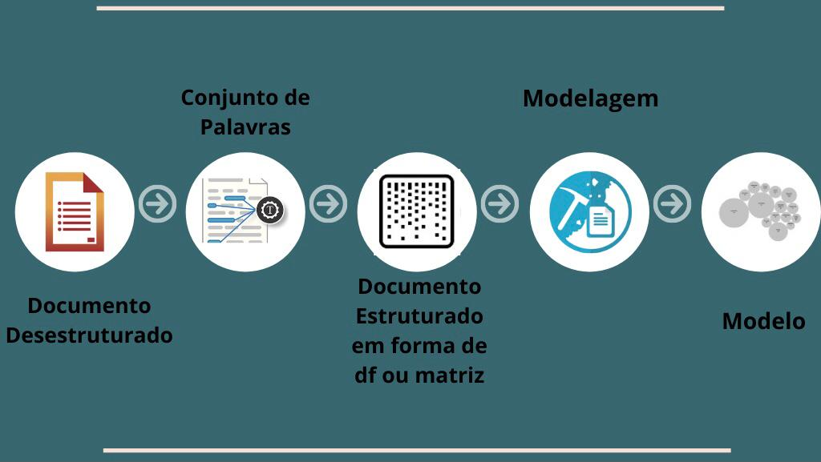

## Importância do Text Mining

- Os analistas normalmente trabalham com dados numéricos e, em sua maioria, organizados tabularmente, contudo, grande parte de dados, principalmente quando estão em formato de texto, se encontram desestruturados. Nesse sentido, é crucial o uso dos text mining tanto pra estudo quanto para organização desses elementos;
- Com a quantidade de informações emitidas a cada segundo por todos os cantos do mundo, é por meio do text mining que conseguimos extrair essa imensa quantidade de opiniões em formato de dados, informações essas muito importantes, tendo em vista que não se encontram em pesquisas tradicionais;
- Aplicação prática: análise de dados instantâneos gerados nas redes sociais.

## Pacotes usados

- **Pacote** `tidytext`: permite a conversão de dados textuais em sua forma bruta para um modelo em dataframe ou, mais normalmente, para um tibble; (“nos permitindo manipular, resumir e visualizar as características de um texto”)
- **Pacote** `tm`: disponibiliza funções e datasets que facilitam a análise de textos, como um “dicionário” de stopwords (as palavras que não serão analisadas por não terem relevância – as, os, sem, com), sendo assim mais completo que o tidy text;
- **Pacote** `rtweet`: Provê diversas (“diversas mesmo”) informações sobre tweets a partir de uma API obtida externamente;
- **Pacote** `wordcloud`: permite a criação de diferentes gráficos baseados em nuvens de palavras;
- **Pacote** `cluster`: usado para a segmentação dos dados em grupos baseados em sua similaridade;
- Além de outros pacotes usados são os padrões de toda análise (`tidyverse`, `dplyr`, `stringr`, `rechape2`, `ggplot2`, entre outros).

## Convertendo dados para Text Mining

## O formato tidy text

### Dados tidy tem um estrutura específica:

- Cada variável é uma coluna;
- Cada observação é um **row**;
- Cada tipo de unidade de observação é um **table**.

#### O format tidy text é definido como um **table** com um **token** por **row**.

- Um **token** é uma unidade de texto com significado, podendo ser uma palavra, uma frase entre outros.

### Esse formato tidy contrasta com outras formas de armazenagem de texto como:

- *String*: Normalmente, os dados de texto são primeiramente lidos neste formato;
- *Corpus*: Esses tipos de objetos, geralmente, contêm strings brutas anotadas com metadados e detalhes adicionais;
- *Document-term matrix*: Esta é uma matriz que descreve uma coleção (ou seja, um corpus) de documentos com uma linha para cada documento e uma coluna para cada termo. O valor na matriz é normalmente a contagem de palavras ou tf-idf.

## O formato tidy text

### Funções utilizadas para transformar o dado em formato tidy

- Transformar dados em tokens: Em nossa estrutura de texto organizada, precisamos dividir o texto em tokens individuais (um processo chamado tokenização) e transformá-lo em uma estrutura de dados organizada. Para fazer isso, usamos a função `unnest_tokens()` de tidytext.

### Função `unnest_tokens()`:

- Primeiro nome da coluna de output, depois a coluna de input;
- Por default converte em *lowercase*.

### Um exemplo:

```r
 text <- c("Because I could not stop for Death -",
           "He kindly stopped for me -",
           "The Carriage held but just Ourselves -",
           "and Immortality")

library(dplyr)
text_df <- tibble(line = 1:4, text = text)
head(text_df)
```

```
## # A tibble: 4 x 2
##    line text
##   <int> <chr>
## 1     1 Because I could not stop for Death -
## 2     2 He kindly stopped for me -
## 3     3 The Carriage held but just Ourselves -
## 4     4 and Immortality
```

```r
library(tidytext)
text_df %>%
  unnest_tokens(word, text)
```

```
## # A tibble: 20 x 2
##     line word
##    <int> <chr>
##  1     1 because
##  2     1 i
##  3     1 could
##  4     1 not
##  5     1 stop
##  6     1 for
##  7     1 death
##  8     2 he
##  9     2 kindly
## 10     2 stopped
## 11     2 for
## 12     2 me
## 13     3 the
## 14     3 carriage
## 15     3 held
## 16     3 but
## 17     3 just
## 18     3 ourselves
## 19     4 and
## 20     4 immortality
```

```r
head(text_df)
```

```
## # A tibble: 4 x 2
##    line text
##   <int> <chr>
## 1     1 Because I could not stop for Death -
## 2     2 He kindly stopped for me -
## 3     3 The Carriage held but just Ourselves -
## 4     4 and Immortality
```

### Outro exemplo:

```r
library(tidytext)
library(dplyr)
library(janeaustenr)

d <- tibble(txt = prideprejudice)
d %>%
  unnest_tokens(word, txt)
```

```
## # A tibble: 122,204 x 1
##    word
##    <chr>
##  1 pride
##  2 and
##  3 prejudice
##  4 by
##  5 jane
##  6 austen
##  7 chapter
##  8 1
##  9 it
## 10 is
## # ... with 122,194 more rows
```

```r
d %>%
  unnest_tokens(sentence, txt, token = "sentences")
```

```
## # A tibble: 15,545 x 1
##    sentence
##    <chr>
##  1 "pride and prejudice"
##  2 "by jane austen"
##  3 "chapter 1"
##  4 "it is a truth universally acknowledged, that a single man in possession"
##  5 "of a good fortune, must be in want of a wife."
##  6 "however little known the feelings or views of such a man may be on his"
##  7 "first entering a neighbourhood, this truth is so well fixed in the minds"
##  8 "of the surrounding families, that he is considered the rightful property"
##  9 "of some one or other of their daughters."
## 10 "\"my dear mr."
## # ... with 15,535 more rows
```

```r
d %>%
  unnest_tokens(ngram, txt, token = "ngrams", n = 2)
```

```
## # A tibble: 114,045 x 1
##    ngram
##    <chr>
##  1 pride and
##  2 and prejudice
##  3 <NA>
##  4 by jane
##  5 jane austen
##  6 <NA>
##  7 <NA>
##  8 <NA>
##  9 chapter 1
## 10 <NA>
## # ... with 114,035 more rows
```

```r
d %>%
  unnest_tokens(chapter, txt, token = "regex",
                pattern = "Chapter [\\\\d]")
```

```
## # A tibble: 10,721 x 1
##    chapter
##    <chr>
##  1 "pride and prejudice"
##  2 "by jane austen"
##  3 "chapter 1"
##  4 "it is a truth universally acknowledged, that a single man in possession"
##  5 "of a good fortune, must be in want of a wife."
##  6 "however little known the feelings or views of such a man may be on his"
##  7 "first entering a neighbourhood, this truth is so well fixed in the minds"
##  8 "of the surrounding families, that he is considered the rightful property"
##  9 "of some one or other of their daughters."
## 10 "\"my dear mr. bennet,\" said his lady to him one day, \"have you heard that"
## # ... with 10,711 more rows
```

```r
d %>%
  unnest_tokens(shingle, txt, token = "character_shingles",
                n = 4)
```

```
## # A tibble: 506,732 x 1
##    shingle
##    <chr>
##  1 prid
##  2 ride
##  3 idea
##  4 dean
##  5 eand
##  6 andp
##  7 ndpr
##  8 dpre
##  9 prej
## 10 reju
## # ... with 506,722 more rows
```

```r
# custom function
d %>%
  unnest_tokens(word, txt, token = stringr::str_split,
                pattern = " ")
```

```
## # A tibble: 124,032 x 1
##    word
##    <chr>
##  1 "pride"
##  2 "and"
##  3 "prejudice"
##  4 ""
##  5 "by"
##  6 "jane"
##  7 "austen"
##  8 ""
##  9 ""
## 10 ""
## # ... with 124,022 more rows
```

```r
# tokenize HTML
h <- tibble(row = 1:2,
                text = c("<h1>Text <b>is</b>",
                         "<a href='example.com'>here</a>"))

h %>%
  unnest_tokens(word, text, format = "html")
```

```
## # A tibble: 3 x 2
##     row word
##   <int> <chr>
## 1     1 text
## 2     1 is
## 3     2 here
```

## O formato tidy text

### Função `anti_join()`:

- Pode ser utilizada para remover palavras frequentes que não são importantes para a análise, tais como: “the”, “of”, “to”. Essas são chamadas de stop_words.

```r
library(gutenbergr)
hgwells <- gutenberg_download(c(35, 36, 5230, 159))
#Pegando romances do autor Gutenberg pelo seu ID

head(hgwells)
```

```
## # A tibble: 6 x 2
##   gutenberg_id text
##          <int> <chr>
## 1           35 "The Time Machine"
## 2           35 ""
## 3           35 "An Invention"
## 4           35 ""
## 5           35 "by H. G. Wells"
## 6           35 ""
```

```r
library(gutenbergr)
tidy_hgwells <- hgwells %>%
    unnest_tokens(word, text) %>%
    anti_join(stop_words)
head(tidy_hgwells)
```

```
## # A tibble: 6 x 2
##   gutenberg_id word
##          <int> <chr>
## 1           35 time
## 2           35 machine
## 3           35 invention
## 4           35 contents
## 5           35 introduction
## 6           35 ii
```

## O formato tidy text

### Função `count()`:

- Essa função é utilizada para contar o número de vezes que um token aparece.

```r
tidy_hgwells %>%
  count(word, sort = TRUE)
```

```
## # A tibble: 11,830 x 2
##    word       n
##    <chr>  <int>
##  1 time     461
##  2 people   302
##  3 door     260
##  4 heard    249
##  5 black    232
##  6 stood    229
##  7 white    224
##  8 hand     218
##  9 kemp     213
## 10 eyes     210
## # ... with 11,820 more rows
```

## O formato tidy text

- Formato facilita a manipulação dos dados utilizando tidy tools como dplyr, tidyr, and ggplot2 para explorar e visualizar dados de texto.

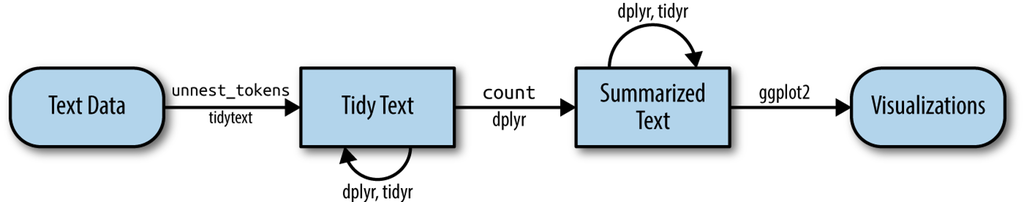

## O formato tidy text

- Entrentato, a maioria das ferramentas de R para Natural Language Processing, NPL, não são compatíveis com esse formato;
- A imagem a seguir mostra o fluxo que combina a aplicação tidy com outras formas de dados.

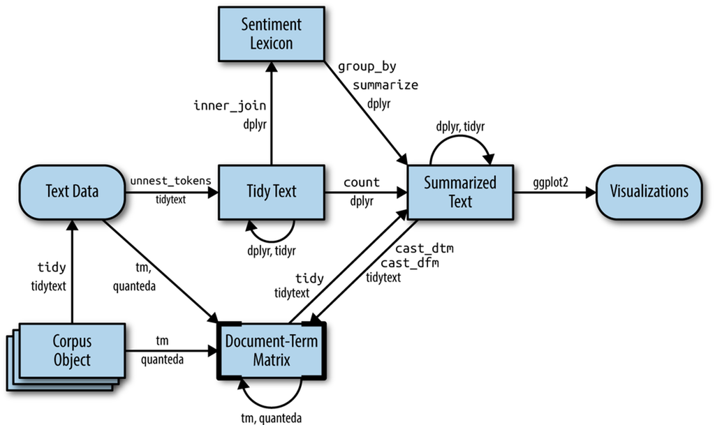

## O formato Document-Term Matrix

- O DMT é uma das estruturas mais comuns para se trabalhar com os pacotes de text mining.

#### Consiste em:

- Cada row representa um documento (como um livro ou artigo);
- Cada coluna representa um termo
- Cada valor contem o número de aparições do termo no documento

#### Como mencionado objetos DMT não pode ser manipulados diretamente por tidy tools. Porém o pacote tidytext fornece dois verbos que convertem ambos formatos.

- `tidy()`: transforma o DMT em tidy data frame.
- `cast()`: transforma o tidy em matrix.

## Organizando objetos Document-Term Matrix

```r
library(tm)

data("AssociatedPress", package = "topicmodels")
AssociatedPress
```

```
## <<DocumentTermMatrix (documents: 2246, terms: 10473)>>
## Non-/sparse entries: 302031/23220327
## Sparsity           : 99%
## Maximal term length: 18
## Weighting          : term frequency (tf)
```

## Organizando objetos Document-Term Matrix

```r
terms <- Terms(AssociatedPress)
head(terms)
```

```
## [1] "aaron"      "abandon"    "abandoned"  "abandoning" "abbott"
## [6] "abboud"
```

## Organizando objetos Document-Term Matrix

```r
library(dplyr)
library(tidytext)

ap_td <- tidy(AssociatedPress)
head(ap_td, n=6L)
```

```
## # A tibble: 6 x 3
##   document term      count
##      <int> <chr>     <dbl>
## 1        1 adding        1
## 2        1 adult         2
## 3        1 ago           1
## 4        1 alcohol       1
## 5        1 allegedly     1
## 6        1 allen         1
```

## Organizando objetos Document-Term Matrix

```r
ap_sentiments <- ap_td %>%
  inner_join(get_sentiments("bing"), by = c(term = "word"))

head (ap_sentiments)
```

```
## # A tibble: 6 x 4
##   document term    count sentiment
##      <int> <chr>   <dbl> <chr>
## 1        1 assault     1 negative
## 2        1 complex     1 negative
## 3        1 death       1 negative
## 4        1 died        1 negative
## 5        1 good        2 positive
## 6        1 illness     1 negative
```

## Organizando objetos Document-Term Matrix

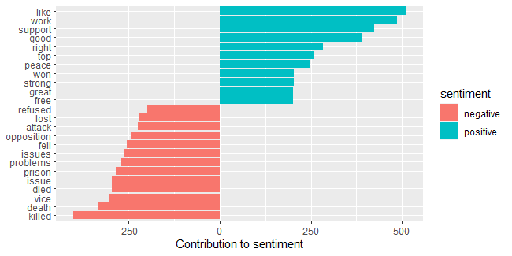

## Organizando objetos Document-Term Matrix

- *Pacote quanteda*

```r
data("data_corpus_inaugural", package = "quanteda")
inaug_dfm <- quanteda::dfm(data_corpus_inaugural, verbose = FALSE)
inaug_dfm
```

```
## Document-feature matrix of: 59 documents, 9,439 features (91.84% sparse) and 4 docvars.
##                  features
## docs              fellow-citizens  of the senate and house representatives :
##   1789-Washington               1  71 116      1  48     2               2 1
##   1793-Washington               0  11  13      0   2     0               0 1
##   1797-Adams                    3 140 163      1 130     0               2 0
##   1801-Jefferson                2 104 130      0  81     0               0 1
##   1805-Jefferson                0 101 143      0  93     0               0 0
##   1809-Madison                  1  69 104      0  43     0               0 0
##                  features
## docs              among vicissitudes
##   1789-Washington     1            1
##   1793-Washington     0            0
##   1797-Adams          4            0
##   1801-Jefferson      1            0
##   1805-Jefferson      7            0
##   1809-Madison        0            0
## [ reached max_ndoc ... 53 more documents, reached max_nfeat ... 9,429 more features ]
```

## Organizando objetos Document-Term Matrix

```r
inaug_td <- tidy(inaug_dfm)
inaug_td
```

```
## # A tibble: 45,453 x 3
##    document        term            count
##    <chr>           <chr>           <dbl>
##  1 1789-Washington fellow-citizens     1
##  2 1797-Adams      fellow-citizens     3
##  3 1801-Jefferson  fellow-citizens     2
##  4 1809-Madison    fellow-citizens     1
##  5 1813-Madison    fellow-citizens     1
##  6 1817-Monroe     fellow-citizens     5
##  7 1821-Monroe     fellow-citizens     1
##  8 1841-Harrison   fellow-citizens    11
##  9 1845-Polk       fellow-citizens     1
## 10 1849-Taylor     fellow-citizens     1
## # ... with 45,443 more rows
```

## Casting tidy text data into a matrix

### Família `cast_()`

- Converter os dados tidy para dtm.

```r
ap_td %>%
  cast_dtm(document, term, count)
```

```
## <<DocumentTermMatrix (documents: 2246, terms: 10473)>>
## Non-/sparse entries: 302031/23220327
## Sparsity           : 99%
## Maximal term length: 18
## Weighting          : term frequency (tf)
```

## Casting tidy text data into a matrix

- Converter a tabela em um dtm objeto do dtm de `quanteda` com `cast_dfm()`.

```r
ap_td %>%
  cast_dfm(document, term, count)
```

```
## Document-feature matrix of: 2,246 documents, 10,473 features (98.72% sparse) and 0 docvars.
##     features
## docs adding adult ago alcohol allegedly allen apparently appeared arrested
##    1      1     2   1       1         1     1          2        1        1
##    2      0     0   0       0         0     0          0        1        0
##    3      0     0   1       0         0     0          0        1        0
##    4      0     0   3       0         0     0          0        0        0
##    5      0     0   0       0         0     0          0        0        0
##    6      0     0   2       0         0     0          0        0        0
##     features
## docs assault
##    1       1
##    2       0
##    3       0
##    4       0
##    5       0
##    6       0
## [ reached max_ndoc ... 2,240 more documents, reached max_nfeat ... 10,463 more features ]
```

## Arrumando objetos corpus com metadados

- Algumas estruturas de dados são projetadas para armazenar coleções de documentos antes da tokenização, geralmente chamadas de “corpus”;
- Um objeto corpus é estruturado como uma lista, com cada item contendo texto e metadado.

#### Eles armazenam texto junto com metadados, que podem incluir:

- um ID;
- data / hora;
- título ou idioma para cada documento.

## Arrumando objetos corpus com metadados

```r
data("acq")
acq
```

```
## <<VCorpus>>
## Metadata:  corpus specific: 0, document level (indexed): 0
## Content:  documents: 50
```

## Arrumando objetos corpus com metadados

```r
acq_td <- tidy(acq)
acq_td
```

```
## # A tibble: 50 x 16
##    author datetimestamp       description heading id    language origin topics
##    <chr>  <dttm>              <chr>       <chr>   <chr> <chr>    <chr>  <chr>
##  1 <NA>   1987-02-26 12:18:06 ""          COMPUT~ 10    en       Reute~ YES
##  2 <NA>   1987-02-26 12:19:15 ""          OHIO M~ 12    en       Reute~ YES
##  3 <NA>   1987-02-26 12:49:56 ""          MCLEAN~ 44    en       Reute~ YES
##  4 By Ca~ 1987-02-26 12:51:17 ""          CHEMLA~ 45    en       Reute~ YES
##  5 <NA>   1987-02-26 13:08:33 ""          <COFAB~ 68    en       Reute~ YES
##  6 <NA>   1987-02-26 13:32:37 ""          INVEST~ 96    en       Reute~ YES
##  7 By Pa~ 1987-02-26 13:43:13 ""          AMERIC~ 110   en       Reute~ YES
##  8 <NA>   1987-02-26 13:59:25 ""          HONG K~ 125   en       Reute~ YES
##  9 <NA>   1987-02-26 14:01:28 ""          LIEBER~ 128   en       Reute~ YES
## 10 <NA>   1987-02-26 14:08:27 ""          GULF A~ 134   en       Reute~ YES
## # ... with 40 more rows, and 8 more variables: lewissplit <chr>,
## #   cgisplit <chr>, oldid <chr>, places <named list>, people <lgl>, orgs <lgl>,
## #   exchanges <lgl>, text <chr>
```

## Arrumando objetos corpus com metadados

```r
acq_tokens <- acq_td %>%
  select(-places) %>%
  unnest_tokens(word, text) %>%
  anti_join(stop_words, by = "word")

# most common words
acq_tokens %>%
  count(word, sort = TRUE)
```

```
## # A tibble: 1,566 x 2
##    word         n
##    <chr>    <int>
##  1 dlrs       100
##  2 pct         70
##  3 mln         65
##  4 company     63
##  5 shares      52
##  6 reuter      50
##  7 stock       46
##  8 offer       34
##  9 share       34
## 10 american    28
## # ... with 1,556 more rows
```

## Técnicas de análise com tweets

## Limpeza dos dados

### Queremos apenas dados que forneçam informações pertinentes

- Pontuações;
- Stopwords - `tidytext::stop_words`;
- Diferenciação maiúsculas / minúsculas.

## Exemplificação: Análise de tweets

### Extração interna

```
install.packages("rtweet")
library(rtweet)
```

- Com a devida API, temos à disposição diversas informações sobre tweets dos últimos dias a partir da função acima.

```r
#Uso para 10000 tweets para teste
tweets = search_tweets("superman", include_rts = FALSE, n = 10000,
                       lang = "en")
```

## Exemplificação: Análise de tweets

- Tweets em inglês são mais fáceis de analisar, uma vez que é menor a variação na forma das palavras:

*bonito/bonita/bonitos/bonitas vs beautiful*

- Mesmo quando consideramos expressões regulares, a partir do radical das palavras, as dificuldades continuam.
- Os dados em formato `data_frame()` permitem manipulação direta.

```r
tweets %>%
  ts_plot("1 hour") +
  theme_minimal() +
  theme(plot.title = element_text(face = "bold")) +
  labs(
    x = NULL, y = NULL,
    title = "Frequencia de Twitter posts",
    subtitle = "Tweets a cada hora pelo horário de Greenwich.",
    caption = "\nSource: Dados coletados pela API do Twitter"
  )
```

[figure not shown]

## Exemplificação: Análise de tweets

### Primeiro tratamento

- Retirada das “stopwords”:

```r
twitter_text = tweets$text #Consideramos apenas o texto do tweet
lixo = stop_words$word
```

## Exemplificação: Análise de tweets

### Primeiro tratamento

- Forma Corpus e limpeza geral:

```r
twitter_text_corpus = VCorpus(VectorSource(twitter_text))

twitter_text_corpus = tm_map(twitter_text_corpus,
                             content_transformer(tolower))

twitter_text_corpus = tm_map(twitter_text_corpus, removePunctuation)

twitter_text_corpus = tm_map(twitter_text_corpus,removeWords, lixo)

twitter_text_corpus = tm_map(twitter_text_corpus,removeNumbers)

palavras = c("superman","dont","don","people", "so")

twitter_text_corpus = tm_map(twitter_text_corpus,removeWords, palavras)
```

## Wordcloud: análise da frequência

- `library(wordcloud)`

```r
wordcloud(twitter_text_corpus, min.freq=30,
          max.words = 200, random.order = F)
```

[figure not shown]

## Wordcloud: análise da frequência

### Que problemas podemos enxergar com o gráfico?

- Obviedades;
- Redundâncias;
- Excesso de termos de pouca frequência;
- Estética não agradável.

## Estruturação Document-Term Matrix

- É bastante útil para a visualização de clusters.

```r
twitter_dtm = DocumentTermMatrix(twitter_text_corpus)
twitter_freq = colSums(as.matrix(twitter_dtm))
```

### Limpeza mais profunda:

```r
twitter_dtm = removeSparseTerms(twitter_dtm, 0.98)
twitter_freq = sort(colSums(as.matrix(twitter_dtm)), decreasing = T)
```

## Estruturação Document-Term Matrix

- Volta-se ao formato data_frame para os plots

```r
twitter_df = data.frame(word = names(twitter_freq), freq = twitter_freq)
```

- Observa-se uma melhora considerável na distribuição das palavras Porém, as redundâncias ainda incomodam e sugerem interpretações equivocadas.

```r
ggplot(subset(twitter_df,freq > 500), aes(x = reorder(word,-freq),
                                          y = freq))+
  geom_bar(stat = "identity")+
  labs(x = "Termos", y = "Frequencia")+
  theme(axis.text.x=element_text(angle=90,hjust=1,vjust=0.5))
```

## Estruturação Document-Term Matrix

[figure not shown]

## Estruturação Document-Term Matrix

- Que tal agora?

```r
twitter_df[twitter_df$word == c("characters"),1] <- c("character")
twitter_df = aggregate(freq~word,data=twitter_df,FUN=sum)
twitter_df <- twitter_df %>%
  filter(word != c("dont", "don", "people", "superman", "so"))

grafico = ggplot(subset(twitter_df,freq > 70),
                 aes(x = reorder(word,-freq), y = freq))+
  geom_bar(stat = "identity")+
  labs(x = "Termos", y = "Frequencia")
```

## Estruturação Document-Term Matrix

- Nova núvem de palavras

```r
formatacao = brewer.pal(8, "Dark2")
wordcloud(twitter_df$word,twitter_df$freq,min.freq=20, max.words = 50,
          random.order = F, colors = formatacao)
```

[figure not shown]

- Por várias razões, pode ser interessante representar os termos a partir de seus grupos de semelhança.
- `library(cluster)`

## Análise de sentimentos

- Diferentes lêxicos, para diferentes línguas
- Em português (limitações já descritas)
- `LexiconOT:: oplexicon_v3.0`

```r
sentimentos <- oplexicon_v3.0 %>%
  select(term, polarity) %>%
  rename(word = term)
word = stopwords("pt")
palavras_vazias <- as.data.frame(word)

tweets_pt <- search_tweets("vacina", include_rts = FALSE, n = 1000,
                       lang = "pt")

an_sentimentosPT <- tweets_pt %>%
  unnest_tokens(word,text,token = "tweets") %>%
  select(user_id,status_id,created_at,screen_name,word) %>%
  anti_join(palavras_vazias) %>%
  inner_join(sentimentos) %>%
  mutate(polarity = as.factor(polarity)) %>%
  count(word,polarity) %>%
  acast(word ~ polarity, value.var = "n", fill = 0) %>%
  comparison.cloud(colors = brewer.pal(8, "Dark2"),
                   max.words = 100)
```

[figure not shown]

## Análise de sentimentos

- Em inglês
- `tidytext:: get_sentiments("bing")`:

```r
an_sentimentosEN <- tweets %>%
  unnest_tokens(word,text,token = "tweets") %>%
  select(user_id,status_id,created_at,screen_name,word) %>%
  anti_join(stop_words) %>%
  inner_join(get_sentiments("bing")) %>%
  count(word,sentiment) %>%
  acast(word ~ sentiment, value.var = "n", fill = 0) %>%
  comparison.cloud(colors = brewer.pal(8, "Set1"),
                   max.words = 100)
```

[figure not shown]

## Análise com Bigramas

- Vamos para o R!

## Bibliografia

- [Livro sobre Text Mining](https://www.tidytextmining.com/index.html)
- [Site sobre Data Science](https://towardsdatascience.com/)
- [TCC sobre Text Mining](https://www.lume.ufrgs.br/bitstream/handle/10183/149102/001004730.pdf?sequence=1)